# Bayesian DEB Modelling of Eisenia fetida Growth and DEBtox Analysis

Branimir K. Hackenberger, Tamara Djerdj, Domagoj K. Hackenberger

2026-05-11

> **Illustrative settings.** To keep build time within CRAN’s vignette limits the chunks below use 2 chains × (300 + 300) iterations on a 5-individual subset of `eisenia_growth`. The publication-grade analysis with 4 chains × (1000 + 1000) iterations on all 21 individuals is reproduced by the scripts in the replication archive (`BayesianDEB_replication.zip`).

# 1 Introduction

Dynamic Energy Budget (DEB) theory provides a mechanistic, thermodynamically consistent framework for describing how organisms acquire and utilise energy for maintenance, growth, development, and reproduction (Kooijman 2010). Classical DEB calibration relies on deterministic optimisation, yielding a single best-fit parameter vector without formal uncertainty quantification.

**BayesianDEB** embeds the DEB ordinary differential equation (ODE) system within a Bayesian state-space model, using Stan’s Hamiltonian Monte Carlo (HMC) sampler (Carpenter et al. 2017) to explore the full joint posterior distribution of all parameters. This approach naturally provides:

- **Uncertainty propagation** to derived quantities (ultimate length, EC<sub>50</sub>, NEC).
- **Prior incorporation** of biological knowledge from the AmP collection (Marques et al. 2018) or previous studies.
- **Hierarchical modelling** with partial pooling across individuals (Gelman and Hill 2006).
- **Model checking** through posterior predictive checks (Gelman et al. 2013, Ch. 6).

This vignette demonstrates the complete workflow on two standard ecotoxicological test organisms:

1. *Eisenia fetida* (earthworm) — individual growth model, then a hierarchical multi-individual analysis.
2. *DEBtox analysis* — toxicokinetic-toxicodynamic (TKTD) model on growth data under toxicant exposure, with EC<sub>50</sub>/NEC estimation.

# 2 Prerequisites

```r
library(BayesianDEB)
library(ggplot2)
library(posterior)  # for summarise_draws()
```

BayesianDEB requires **cmdstanr** and a working CmdStan installation for model fitting. Data preparation, prior specification, and utility functions work without Stan.

```r
# Internal helper; emits an informative error when CmdStan is missing.
BayesianDEB:::check_cmdstanr()
```

# 3 Part 1: *Eisenia fetida* Growth

## 3.1 Data description

The `eisenia_growth` dataset contains simulated weekly length measurements for 21 *Eisenia fetida* individuals over 84 days (12 weeks). The simulation used the standard 2-state DEB model (reserve $E$, structure $V$) with parameters representative of *E. fetida* from the AmP collection: $\{p_{Am}\} = 5.0$ J d$^{-1}$ cm$^{-2}$, $[p_M] = 0.5$ J d$^{-1}$ cm$^{-3}$, $\kappa = 0.75$, $v = 0.2$ cm d$^{-1}$, $[E_G] = 400$ J cm$^{-3}$. Individual variation in $\{p_{Am}\}$ (CV $\approx$ 10%) and Gaussian observation error ($\sigma_L = 0.015$ cm) were added.

```r
data(eisenia_growth)

# Structure: 273 obs, 3 variables (id, time, length)
str(eisenia_growth)
```

```
#> 'data.frame':    273 obs. of  3 variables:
#>  $ id    : int  1 1 1 1 1 1 1 1 1 1 ...
#>  $ time  : num  0 7 14 21 28 35 42 49 56 63 ...
#>  $ length: num  0.103 0.109 0.11 0.107 0.137 ...
```

```r
length(unique(eisenia_growth$id))   # 21 individuals
```

```
#> [1] 21
```

```r
length(unique(eisenia_growth$time)) # 13 time points (days 0–84)
```

```
#> [1] 13
```

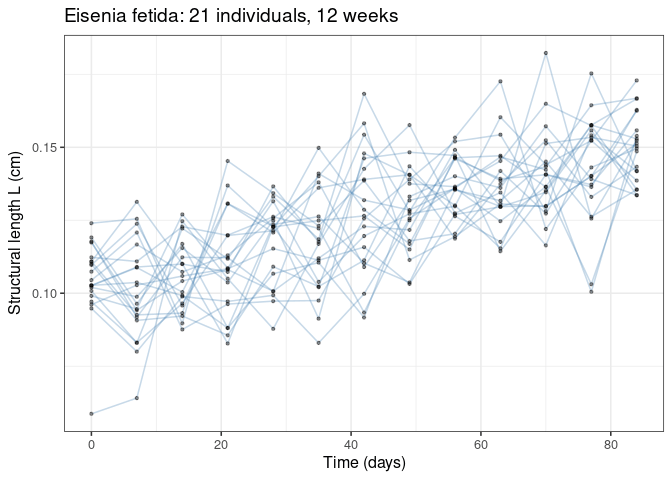

Growth trajectories of 21 *E. fetida* individuals. Structural length $L = V^{1/3}$ measured weekly over 12 weeks.

```r
ggplot(eisenia_growth, aes(time, length, group = id)) +
  geom_line(alpha = 0.3, colour = "steelblue") +
  geom_point(size = 0.8, alpha = 0.4) +
  theme_bw(base_size = 12) +
  labs(x = "Time (days)", y = expression(paste("Structural length ", L, " (cm)")),
       title = "Eisenia fetida: 21 individuals, 12 weeks")
```

Key features visible in the data:

- **Sigmoidal growth** consistent with the DEB prediction $L(t) \to L_\infty$ as $t \to \infty$.
- **Individual variation** in growth rate (spread of trajectories).
- **Measurement noise** visible as scatter around the smooth trend.

## 3.2 Individual model: single organism

We start with a single individual to validate the approach.

### 3.2.1 Step 1: Prepare data

```r
df1 <- eisenia_growth[eisenia_growth$id == 5, ]
dat1 <- bdeb_data(growth = df1, f_food = 1.0)
dat1
```

```
#>
#> ── BDEB Data ──
#>
#> ℹ Individuals: 1
#> ℹ Endpoints: growth
#> ℹ Functional response (f): 1
#> → Growth: 13 observations, t = [0, 84]
```

The `f_food = 1.0` argument specifies ad libitum feeding ($f = 1$, the ratio of actual to maximum ingestion rate; Kooijman 2010, Eq. 2.3).

### 3.2.2 Step 2: Specify model and priors

The individual model tracks two state variables: reserve energy $E$ (J) and structural volume $V$ (cm$^3$), governed by:

$$\frac{dE}{dt} = f\{p_{Am}\}L^2 - \frac{EvL}{E + [E_G]V},
\qquad
\frac{dV}{dt} = \frac{\kappa \dot{p}_C - [p_M]V}{[E_G]}$$

where $L = V^{1/3}$ is structural length. Observed lengths are assumed to follow $L_\text{obs} \sim \mathcal{N}(\hat{L}, \sigma_L)$.

We set biologically informed priors based on published AmP values for earthworms:

| Parameter | Prior | Rationale |
| --- | --- | --- |
| $\{p_{Am}\}$ | LogNormal(1.5, 0.5) | Median $e^{1.5} \approx 4.5$; AmP range 3–8 |
| $[p_M]$ | LogNormal(−1.0, 0.5) | Median $e^{-1} \approx 0.37$; typical 0.15–0.8 |
| $\kappa$ | Beta(3, 2) | Mode 0.67; earthworms allocate ~60–80% to soma |
| $v$ | LogNormal(−1.5, 0.5) | Median $e^{-1.5} \approx 0.22$ cm/d |
| $[E_G]$ | LogNormal(6.0, 0.5) | Median $e^6 \approx 403$; typical 200–800 |
| $\sigma_L$ | HalfNormal(0.05) | Measurement precision ~0.01–0.03 cm |

```r
mod1 <- bdeb_model(dat1, type = "individual",
  priors = list(
    p_Am    = prior_lognormal(mu = 1.5, sigma = 0.5),
    p_M     = prior_lognormal(mu = -1.0, sigma = 0.5),
    kappa   = prior_beta(a = 3, b = 2),
    v       = prior_lognormal(mu = -1.5, sigma = 0.5),
    E_G     = prior_lognormal(mu = 6.0, sigma = 0.5),
    sigma_L = prior_halfnormal(sigma = 0.05)
  ))
mod1
```

```
#>
#> ── BDEB Model Specification ──
#>
#> ℹ Type: individual
#> ℹ Stan model: bdeb_individual_growth
#> ℹ Individuals: 1
#> ℹ Endpoints: growth
#>
#> ── Priors
#> →   p_Am: LogNormal(1.5, 0.5)
#> →   p_M: LogNormal(-1.0, 0.5)
#> →   kappa: Beta(3.0, 2.0)
#> →   v: LogNormal(-1.5, 0.5)
#> →   E_G: LogNormal(6.0, 0.5)
#> →   sigma_L: HalfNormal(0.05)
#> →   E0: LogNormal(0.0, 1.0)
#> →   L0: LogNormal(-2.0, 1.0)
```

Unspecified priors (`E0`, `L0`) are filled automatically from `prior_default("individual")`.

### 3.2.3 Step 3: Fit via MCMC

The model is compiled to C++ and sampled using the No-U-Turn Sampler (NUTS; Hoffman and Gelman 2014) with the stiff BDF ODE solver.

```r
fit1 <- bdeb_fit(mod1,
  chains        = 2,
  iter_warmup   = 300,
  iter_sampling = 300,
  refresh       = 100,
  seed          = 42
)
```

[output not shown]

```r
fit1
```

```
#>
#> ── BDEB Fit ──
#>
#> ℹ Model type: individual
#> ℹ Algorithm: sampling (NUTS)
#> ℹ Chains: 2, Warmup: 300, Sampling: 300
#> ✔ No divergent transitions
```

### 3.2.4 Step 4: Convergence diagnostics

Diagnostics follow the recommendations of Vehtari et al. (2021):

```r
diag1 <- bdeb_diagnose(fit1)
```

**What to check:**

- **Divergences = 0** — if present, increase `adapt_delta` (e.g., 0.95).
- **$\hat{R} < 1.01$** for all parameters — chains have mixed.
- **Bulk ESS > 400** — sufficient effective samples for posterior means.
- **Tail ESS > 400** — sufficient for credible interval endpoints.
- **E-BFMI > 0.3** — momentum resampling is efficient.

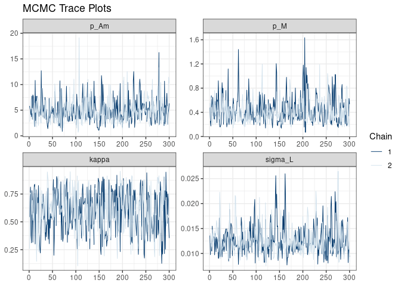

MCMC trace plots for core DEB parameters. Well-mixed chains should appear as overlapping ‘hairy caterpillars’.

```r
plot(fit1, type = "trace",
     pars = c("p_Am", "p_M", "kappa", "sigma_L"))
```

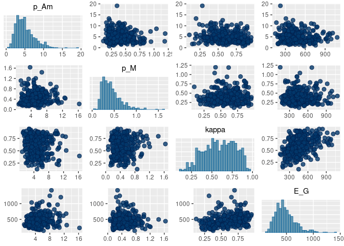

```r
# `bayesplot::mcmc_pairs` requires gridExtra (a Suggests of bayesplot).
plot(fit1, type = "pairs",
     pars = c("p_Am", "p_M", "kappa", "E_G"))
```

### 3.2.5 Step 5: Posterior summary

```r
summary(fit1,
  pars = c("p_Am", "p_M", "kappa", "v", "E_G", "sigma_L"),
  prob = 0.95)
```

```
#> # A tibble: 6 × 9
#>   variable     mean        sd   median    `2.5%` `97.5%`  rhat ess_bulk ess_tail
#>   <chr>       <dbl>     <dbl>    <dbl>     <dbl>   <dbl> <dbl>    <dbl>    <dbl>
#> 1 p_Am       5.00     2.48      4.52     1.63    1.07e+1 0.999     628.     331.
#> 2 p_M        0.428    0.213     0.384    0.161   9.56e-1 1.02      437.     241.
#> 3 kappa      0.593    0.189     0.601    0.220   9.02e-1 1.01      450.     459.
#> 4 v          0.223    0.104     0.201    0.0901  4.63e-1 1.00      543.     490.
#> 5 E_G      475.     185.      441.     201.      9.49e+2 0.998     366.     225.
#> 6 sigma_L    0.0127   0.00298   0.0122   0.00846 2.04e-2 0.998     479.     354.
```

### 3.2.6 Step 6: Posterior predictive check

Posterior predictive checks (PPCs) compare data replicated from the fitted model ($L^\text{rep}$) with the observed data ($L^\text{obs}$). If the model fits well, the observed points should fall within the envelope of replicated trajectories (Gelman et al. 2013, Ch. 6).

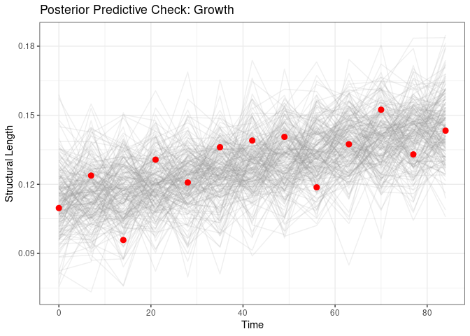

Posterior predictive check: grey lines are replicated growth trajectories, red points are observed data.

```r
ppc1 <- bdeb_ppc(fit1, type = "growth")
plot(ppc1, n_draws = 200)
```

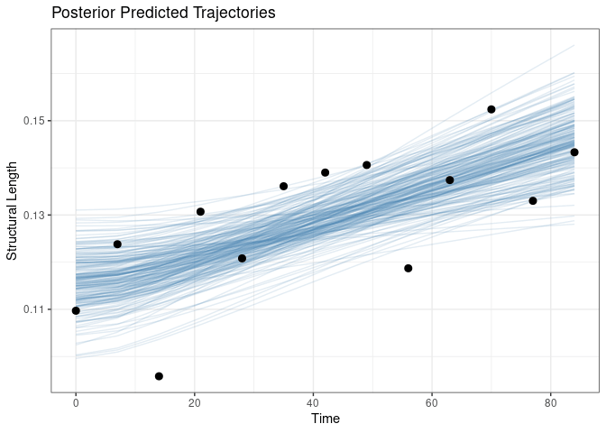

Posterior predicted trajectories (blue) with observed data (black points). The spread reflects parameter uncertainty.

```r
plot(fit1, type = "trajectory", n_draws = 200)
```

### 3.2.7 Step 7: Derived quantities

BayesianDEB computes biologically meaningful quantities directly from the posterior, automatically propagating uncertainty:

| Quantity | Formula | Interpretation |
| --- | --- | --- |
| $L_m$ | $\kappa \{p_{Am}\} / [p_M]$ | Maximum structural length ($f = 1$) |
| $L_\infty$ | $f \cdot L_m$ | Ultimate structural length at food $f$ |
| $k_M$ | $[p_M] / [E_G]$ | Somatic maintenance rate constant |
| $g$ | $[E_G] \, v / (\kappa \{p_{Am}\})$ | Energy investment ratio |
| $\dot{r}_B$ | $k_M \, g \,/\, 3(f + g)$ | von Bertalanffy growth rate (Eq. 3.23) |

Note: all lengths are **structural** ($L = V^{1/3}$), not physical. Physical length $L_w = L / \delta_M$ where $\delta_M$ is the species-specific shape coefficient (not estimated by this package).

```r
der1 <- bdeb_derived(fit1,
  quantities = c("L_m", "L_inf", "k_M", "g", "growth_rate"), f = 1.0)

summarise_draws(der1,
  "mean", "sd",
  "q2.5"  = ~quantile(.x, 0.025),
  "q97.5" = ~quantile(.x, 0.975))
```

```
#> # A tibble: 5 × 5
#>   variable         mean        sd    `2.5%`    `97.5%`
#>   <chr>           <dbl>     <dbl>     <dbl>      <dbl>
#> 1 L_m          8.39      6.58     1.43       26.6
#> 2 L_inf        8.39      6.58     1.43       26.6
#> 3 k_M          0.00104   0.000741 0.000274    0.00290
#> 4 g           55.7      60.7      6.06      226.
#> 5 growth_rate  0.000330  0.000228 0.0000897   0.000917
```

### 3.2.8 Step 8: Scenario analysis — reduced food

How does ultimate size change if food availability drops to 70%? Since $L_\infty \propto f$, we can compute this directly:

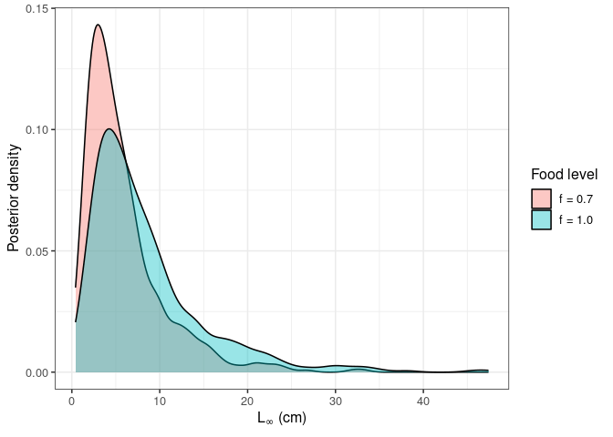

Posterior distributions of $L_\infty$ at $f = 1.0$ (blue) and $f = 0.7$ (orange).

```r
d_f10 <- bdeb_derived(fit1, quantities = "L_inf", f = 1.0)
d_f07 <- bdeb_derived(fit1, quantities = "L_inf", f = 0.7)

df_compare <- data.frame(
  L_inf = c(d_f10$L_inf, d_f07$L_inf),
  food  = rep(c("f = 1.0", "f = 0.7"), each = nrow(d_f10))
)

ggplot(df_compare, aes(x = L_inf, fill = food)) +
  geom_density(alpha = 0.4) +
  theme_bw(base_size = 12) +
  labs(x = expression(L[infinity] ~ "(cm)"),
       y = "Posterior density",
       fill = "Food level")
```

When multiple individuals are available, a hierarchical model is preferred. It estimates population-level distributions for parameters that vary across individuals, while sharing parameters that are species-level constants.

### 3.3.1 Model structure

The hierarchical model places a lognormal random effect on the assimilation rate:

$$\log\{p_{Am}\}_j = \mu_{\log p_{Am}} + \sigma_{\log p_{Am}} \cdot z_j,
\qquad z_j \sim \mathcal{N}(0, 1)$$

This **non-centred parameterisation** (Betancourt and Girolami 2015) avoids the pathological funnel geometry that arises when $\sigma$ is small. The parameters $[p_M]$, $\kappa$, $v$, $[E_G]$ are shared across all individuals.

### 3.3.2 Prepare and specify

```r
# Illustrative subset of 5 individuals; replication archive uses all 21.
dat_all <- bdeb_data(
  growth = eisenia_growth[eisenia_growth$id %in% 1:5, ],
  f_food = 1.0
)
dat_all
```

```
#>
#> ── BDEB Data ──
#>
#> ℹ Individuals: 5
#> ℹ Endpoints: growth
#> ℹ Functional response (f): 1
#> → Growth: 65 observations, t = [0, 84]
```

```r
mod_h <- bdeb_model(dat_all, type = "hierarchical",
  priors = list(
    mu_log_p_Am    = prior_normal(mu = 1.5, sigma = 0.5),
    sigma_log_p_Am = prior_exponential(rate = 2),
    p_M            = prior_lognormal(mu = -1.0, sigma = 0.5),
    kappa          = prior_beta(a = 3, b = 2),
    v              = prior_lognormal(mu = -1.5, sigma = 0.5),
    E_G            = prior_lognormal(mu = 6.0, sigma = 0.5),
    sigma_L        = prior_halfnormal(sigma = 0.05)
  ))
```

The prior on $\sigma_{\log p_{Am}}$ uses an Exponential(2) distribution, following the guidance of Gelman (2006) for hierarchical variance parameters. This places most prior mass near zero while allowing substantial variation if the data support it.

### 3.3.3 Fit

With multiple individuals, each requiring an independent ODE solve per iteration, the hierarchical model benefits from **within-chain parallelism** via Stan’s `reduce_sum` and `threads_per_chain`. We omit threading here because the illustrative subset has only five individuals; the replication archive turns it on for the full 21.

```r
fit_h <- bdeb_fit(mod_h,
  chains        = 2,
  iter_warmup   = 300,
  iter_sampling = 300,
  refresh       = 100,
  seed          = 123
)
```

[output not shown]

### 3.3.4 Diagnostics

```r
bdeb_diagnose(fit_h)
```

```
#>
#> ── BDEB Diagnostics (hierarchical) ──
#>
#> ✔ No divergent transitions.
#> ✔ Treedepth OK.
#> ✔ E-BFMI OK (all > 0.3).
#>
#> ── Parameter Summary
#> ✖ R-hat > 1.01 for: sigma_L
#> ! Low bulk ESS (<400) for: sigma_log_p_Am, v, E_G, L0[2], L0[5], p_Am_ind[5]
#>        variable     mean       sd   median       5%      95%  rhat ess_bulk
#>     mu_log_p_Am   1.6688 4.64e-01   1.6353   0.9608   2.4738 1.007      543
#>  sigma_log_p_Am   0.4320 4.03e-01   0.3213   0.0283   1.2198 1.007      281
#>   z_log_p_Am[1]   0.1377 9.23e-01   0.1524  -1.3863   1.6276 1.002      625
#>   z_log_p_Am[2]   0.5749 1.01e+00   0.6217  -1.1970   2.1104 1.005      420
#>   z_log_p_Am[3]  -0.1276 9.49e-01  -0.1196  -1.5991   1.3257 1.003      667
#>   z_log_p_Am[4]  -0.1208 9.18e-01  -0.1144  -1.5702   1.4193 1.000      504
#>   z_log_p_Am[5]  -0.2189 9.81e-01  -0.2542  -1.7342   1.4531 1.002      548
#>             p_M   0.4625 2.78e-01   0.4004   0.1694   0.9495 1.001      656
#>           kappa   0.6101 1.76e-01   0.6179   0.3265   0.8726 1.007      453
#>             E_G 379.4618 1.41e+02 363.4800 180.1925 637.1423 1.006      350
#>              E0   1.6419 2.20e+00   1.0328   0.2086   4.5229 0.998     1000
#>           L0[1]   0.1089 7.93e-03   0.1095   0.0959   0.1214 0.998      569
#>           L0[2]   0.0878 8.40e-03   0.0883   0.0740   0.1009 1.005      315
#>           L0[3]   0.0975 7.59e-03   0.0975   0.0852   0.1098 1.001      657
#>           L0[4]   0.1026 7.26e-03   0.1024   0.0906   0.1146 0.999      543
#>           L0[5]   0.1092 7.11e-03   0.1089   0.0983   0.1210 1.008      393
#>         sigma_L   0.0168 1.53e-03   0.0167   0.0145   0.0195 1.012      523
#>     p_Am_ind[1]   8.2606 1.34e+01   5.6271   2.2055  21.3419 1.003      573
#>     p_Am_ind[2]  18.0251 1.05e+02   6.9656   2.6570  30.4356 1.007      503
#>     p_Am_ind[3]   6.9626 1.62e+01   5.0160   1.8281  15.4641 1.002      551
#>     p_Am_ind[4]   6.5382 9.70e+00   4.6841   1.8489  13.8376 1.006      440
#>     p_Am_ind[5]   7.1077 1.88e+01   4.6996   1.7037  14.0460 1.010      376
#>  ess_tail
#>       428
#>       368
#>       380
#>       384
#>       231
#>       477
#>       443
#>       524
#>       401
#>       389
#>       414
#>       445
#>       460
#>       306
#>       469
#>       510
#>       445
#>       419
#>       475
#>       375
#>       443
#>       455
#>       383
```

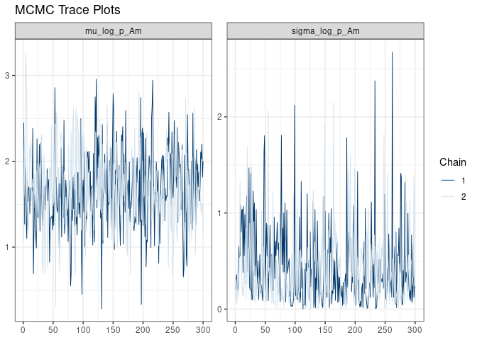

Trace plots for population-level hyperparameters $\mu_{\log p_{Am}}$ and $\sigma_{\log p_{Am}}$.

```r
plot(fit_h, type = "trace",
     pars = c("mu_log_p_Am", "sigma_log_p_Am"))
```

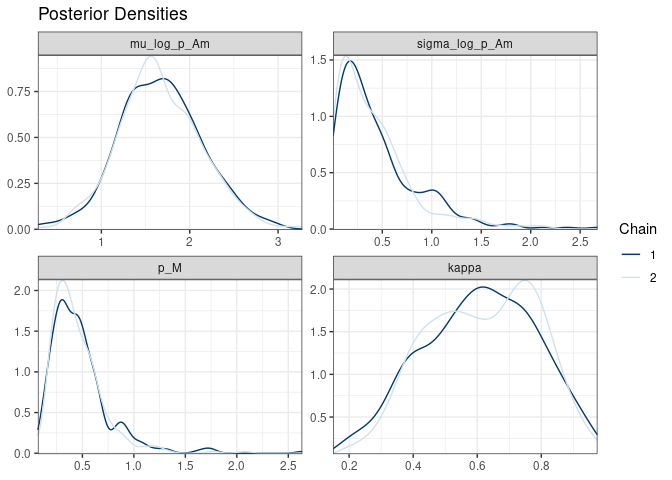

Marginal posterior densities for shared parameters.

```r
plot(fit_h, type = "posterior",
     pars = c("mu_log_p_Am", "sigma_log_p_Am", "p_M", "kappa"))
```